# Homework #6

#### Computing ID: cx2rx

**SYS 6018 | Fall 2020 | University of Virginia**

### Problem 6.1: Customer Segmentation with RFM (Recency, Frequency, and Monetary Value)

RFM analysis is an approach that some businesses use to understand their customers’ activities. At any point in time, a company can measure how recently a customer purchased a product (Recency), how many times they purchased a product (Frequency), and how much they have spent (Monetary Value). There are many ad-hoc attempts to segment/cluster customers based on the RFM scores (e.g., here is one based on using the customers’ rank of each dimension independently: https://joaocorreia.io/blog/rfm-analysis-increase-sales-by-segmenting-your-customers.html). In this problem you will use the clustering methods we covered in class to segment the customers.

The data for this problem can be found here: https://mdporter.github.io/SYS6018/data/RFM.csv. Cluster based on the Recency, Frequency, and Monetary value columns.

1. Implement hierarchical clustering.
   - Describe any pre-processing steps you took (e.g., scaling, distance metric)
   - State the linkage method you used with justification.
   - Show the resulting dendrogram
   - State the number of segments/clusters you used with justification.
   - Using your segmentation, are customers 1 and 100 in the same cluster?

The first step is to read in the data and preview it

```r
data <- read_csv("https://mdporter.github.io/SYS6018/data/RFM.csv")
head(data)
```

```
#> # A tibble: 6 x 4
#>      id Recency Frequency Monetary
#>   <dbl>   <dbl>     <dbl>    <dbl>
#> 1     1     139        13     1147
#> 2     2     447        10      939
#> 3     3     164         7      690
#> 4     4     120        11     1191
#> 5     5     213        13      996
#> 6     6     111         9     1005
```

The next step is to study the distribution of each column:

```r
summary(data)
```

```
#>        id           Recency        Frequency         Monetary
#>  Min.   :    1   Min.   :  2.0   Min.   : 1.000   Min.   :  11.0
#>  1st Qu.: 2501   1st Qu.: 88.0   1st Qu.: 8.000   1st Qu.: 683.0
#>  Median : 5000   Median :149.0   Median :10.000   Median : 915.0
#>  Mean   : 5000   Mean   :181.7   Mean   : 9.814   Mean   : 935.7
#>  3rd Qu.: 7500   3rd Qu.:232.0   3rd Qu.:12.000   3rd Qu.:1155.0
#>  Max.   :10000   Max.   :953.0   Max.   :24.000   Max.   :2422.0
```

We can clearly see that Recency, Frequency and Monetary has very different distributions in terms of the mean values of each column. Therefore, I am going to **scale** them before running the hierarchical cluster analysis. After scaling, I am also going to calculate the pairwise **euclidean** distance for each observations.

```r
# Set seed
set.seed(666)

# Scale the features
X <- data %>%
  select(-id) %>%
  scale()

# Calculate Distance (dissimilarity matrix)
dX <- dist(X, method = "euclidean")

# Run hierarchical clustering
hc <- hclust(dX, method = "centroid")
```

Here I am using the **Centroid Linkage** method to measure the dissimilarity because this is a default approach in hierarchical cluster analysis when we do not have a lot of information about the data we are working with.

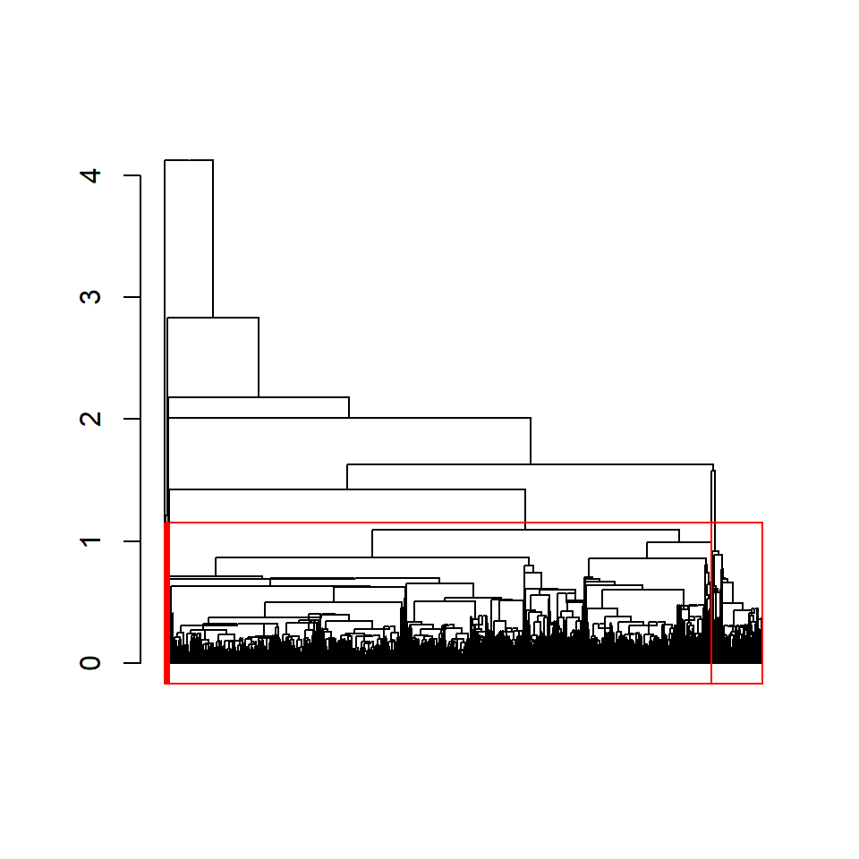

```r
plot(as.dendrogram(hc), leaflab = "none")
rect.hclust(hc, 9, border = "red")
```

After viewing the dendrogram above, we have pretty a good idea about the shape of the tree. Now, we are going to use the “elbow method” to determine the number of clusters for this cluster analysis:

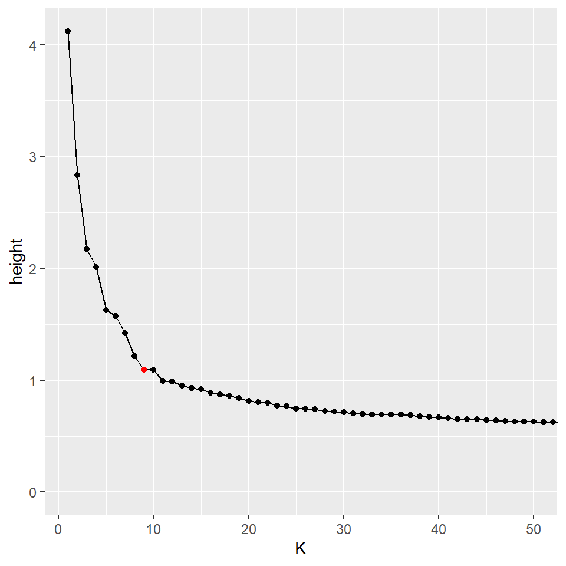

```r
tibble(height = hc$height, K = row_number(-height)) %>%
  ggplot(aes(K, height)) +
  geom_line() +
  geom_point(aes(color = ifelse(K == 9, "red", "black"))) +
  scale_color_identity() +
  coord_cartesian(xlim=c(1, 50))
```

Based on the “elbow method”, I am going to assign 9 customer segments (clusters) to this dataset.

```r
# Extract cluster membership
yhat <- cutree(hc, k = 9)

# Check if customer 1 and customer 100 are in the same cluster
yhat[1] == yhat[100]
```

```
#> [1] TRUE
```

Based on my segmentation, customer 1 and customer 100 are in the same cluster.

2. Implement k-means.
   - Describe any pre-processing steps you took (e.g., scaling)
   - State the number of segments/clusters you used with justification.
   - Using your segmentation, are customers 1 and 100 in the same cluster?

Similar to what I did in hierarchical clustering, I am also going to use the `scale` function to scale the data and then run `kmeans` with multiple K values to figure out the best $K$.

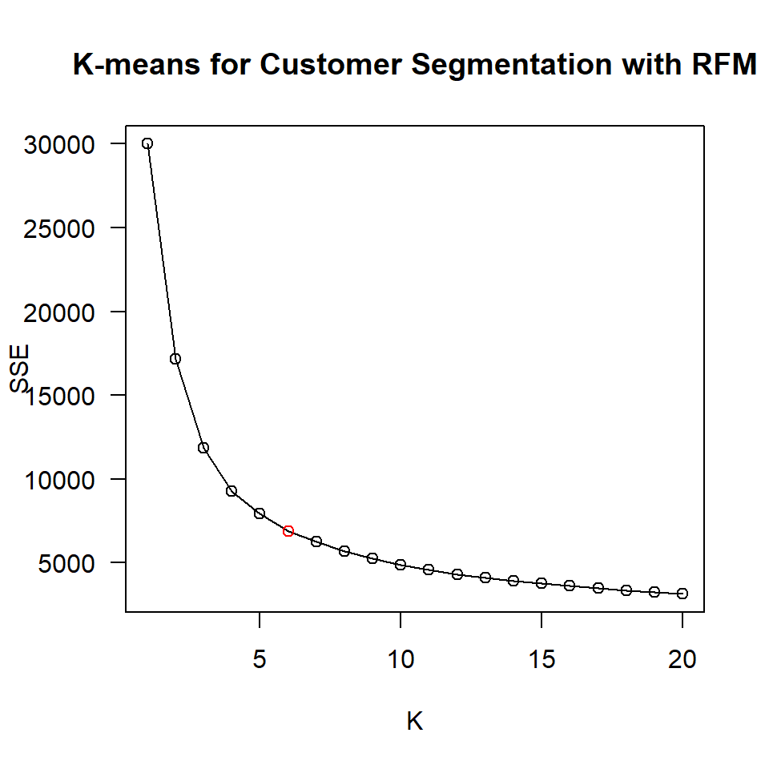

```r
# Set seed
set.seed(666)

# Scale the features
X <- data %>%
  select(-id) %>%
  scale()

# Run Kmeans for multiple k
Kmax = 20
SSE = numeric(Kmax)

for (k in 1:Kmax) {
  km <- kmeans(X, centers = k, nstart = 25)
  SSE[k] = km$tot.withinss
}

# Plot the results
plot(1:Kmax, SSE, type = 'o', las = 1, xlab = "K")
title("K-means for Customer Segmentation with RFM")
points(x = 6, y = SSE[6], col = 'red')
```

Based on the “elbow method”, I am going to assign 6 customer segments (clusters) to this dataset using the Kmeans clustering.

```r
km <- kmeans(X, centers = 6, nstart = 25)
km$cluster[1] == km$cluster[100]
```

```
#> [1] FALSE
```

Based on my segmentation, customer 1 and customer 100 are **not** in the same cluster.

3. Implement model-based clustering
   - Describe any pre-processing steps you took (e.g., scaling)
   - State the number of segments/clusters you used with justification.
   - Describe the best model. What restrictions are on the shape of the components?
   - Using your segmentation, are customers 1 and 100 in the same cluster?

Since we are going to implement model-based clustering, there is no need to do any pre-processing of the data.

```r
# Set seed
set.seed(666)

# Scale the features
X <- data %>%
  select(-id) %>%
  as.matrix()

# Fit series of models
mix <- Mclust(X, verbose = F)

# View the summary
summary(mix)
```

```
#> ----------------------------------------------------
#> Gaussian finite mixture model fitted by EM algorithm
#> ----------------------------------------------------
#>
#> Mclust VVE (ellipsoidal, equal orientation) model with 9 components:
#>
#>  log-likelihood     n df       BIC       ICL
#>       -151838.5 10000 65 -304275.6 -316018.1
#>
#> Clustering table:
#>    1    2    3    4    5    6    7    8    9
#>  946 1227  494 2473  812  670  856 1090 1432
```

- According to the summary information, we know that the model-based clustering generated **9** customer segments/constraints.
- `Mclust` function uses BIC to find the optimal model with largest BIC value and 9 is the best K value it found given all possible constraints.
- The best model has $K = 9$ with VVE constraints.

```r
mix$classification[1] == mix$classification[100]
```

```
#> [1] FALSE
```

Based on my segmentation, customer 1 and customer 100 are **not** in the same cluster.

4. Discuss how you would cluster the customers if you had to do this for your job. Do you think one model would do better than the others?

I think the model-based cluster is better than hierarchical clustering and Kmeans clustering because it has a lot of benefits in terms of model complexity, model constraints, and densities.

### Problem 6.2: Poisson Mixture Model

The pmf of a Poisson random variable is:
$$\begin{align*}
f_k(x; \lambda_k) = \frac{\lambda_k^x e^{-\lambda_k}}{x!}
\end{align*}$$

A two-component Poisson mixture model can be written:
$$\begin{align*}
f(x; \theta) = \pi \frac{\lambda_1^x e^{-\lambda_1}}{x!} + (1-\pi) \frac{\lambda_2^x e^{-\lambda_2}}{x!}
\end{align*}$$

1. What are the parameters of the model?

The model parameters are $\pi$, $\lambda_1$ and $\lambda_2$.

2. Write down the log-likelihood for $n$ independent observations ($x_1, x_2, \ldots, x_n$).

$$\begin{aligned}
log L(\theta) & = \sum_{i = 1}^{n} log f(x_i; \theta) \\
& = \sum_{i = 1}^{n} log \left[ \pi \frac{\lambda_1^x e^{-\lambda_1}}{x_i!} + (1-\pi) \frac{\lambda_2^x e^{-\lambda_2}}{x_i!} \right]
\end{aligned}$$

3. Suppose we have initial values of the parameters. Write down the equation for updating the *responsibilities*.
- Let $K \in \{1, 2\}$ The responsibility $r_{ik}$ is:

$$\begin{aligned}
r_{ik} & = Pr(g_i = k |D, \theta) \\
& = \frac{P(D|g_i = k, \theta_k) \pi_k}{\sum_{j = 1}^K P(D|g_i = j, \theta_j) \pi_j} \\
& = \frac{\frac{\lambda_k^x e^{-\lambda_k}}{x!} \pi}
{\pi \frac{\lambda_1^x e^{-\lambda_1}}{x!} +
(1 - \pi) \frac{\lambda_2^x e^{-\lambda_2}}{x!}}
\end{aligned}$$

4. Suppose we have responsibilities, $r_{ik}$ for all $i=1, 2, \ldots, n$ and $k=1,2$. Write down the equations for updating the parameters.

$$\begin{aligned}
r_{i1} = \frac{\frac{\lambda_1^x e^{-\lambda_1}}{x!} \pi}
{\pi \frac{\lambda_1^x e^{-\lambda_1}}{x!} +
(1 - \pi) \frac{\lambda_2^x e^{-\lambda_2}}{x!}}
\end{aligned}$$
$$\begin{aligned}
r_{i2} & = \frac{\frac{\lambda_2^x e^{-\lambda_2}}{x!} (1 - \pi)}
{\pi \frac{\lambda_1^x e^{-\lambda_1}}{x!} +
(1 - \pi) \frac{\lambda_2^x e^{-\lambda_2}}{x!}}
\end{aligned}$$

$$\pi =\frac{\sum_{i= 1}^n r_{i1}}{N}$$
where $N$ is the number of observations.

5. Fit a two-component Poisson mixture model, report the estimated parameter values, and show a plot of the estimated mixture pmf for the following data:

```r
#-- Run this code to generate the data
set.seed(123)             # set seed for reproducibility
n = 200                   # sample size
z = sample(1:2, size=n, replace=TRUE, prob=c(.25, .75)) # sample the latent class
theta = c(8, 16)          # true parameters
y = ifelse(z==1, rpois(n, lambda=theta[1]), rpois(n, lambda=theta[2]))
```

Note: The function `poisregmixEM()` in the R package `mixtools` is designed to estimate a mixture of *Poisson regression* models. We can still use this function for our problem of density estimation if it is recast as an intercept-only regression. To do so, set the $x$ argument (predictors) to `x = rep(1, length(y))` and `addintercept = FALSE`.

Look carefully at the output from this model. The `beta` values (regression coefficients) are on the log scale.

```r
# Build the Poisson Mixture Model
model <- poisregmixEM(y = y, x = rep(1, length(y)), addintercept = F)
```

```
#> number of iterations= 46
```

```r
# Report the parameters
summary(model)
```

```
#> summary of poisregmixEM object:
#>          comp 1   comp 2
#> lambda 0.728314 0.271686
#> beta1  2.781594 2.064644
#> loglik at estimate:  -611.2228
```

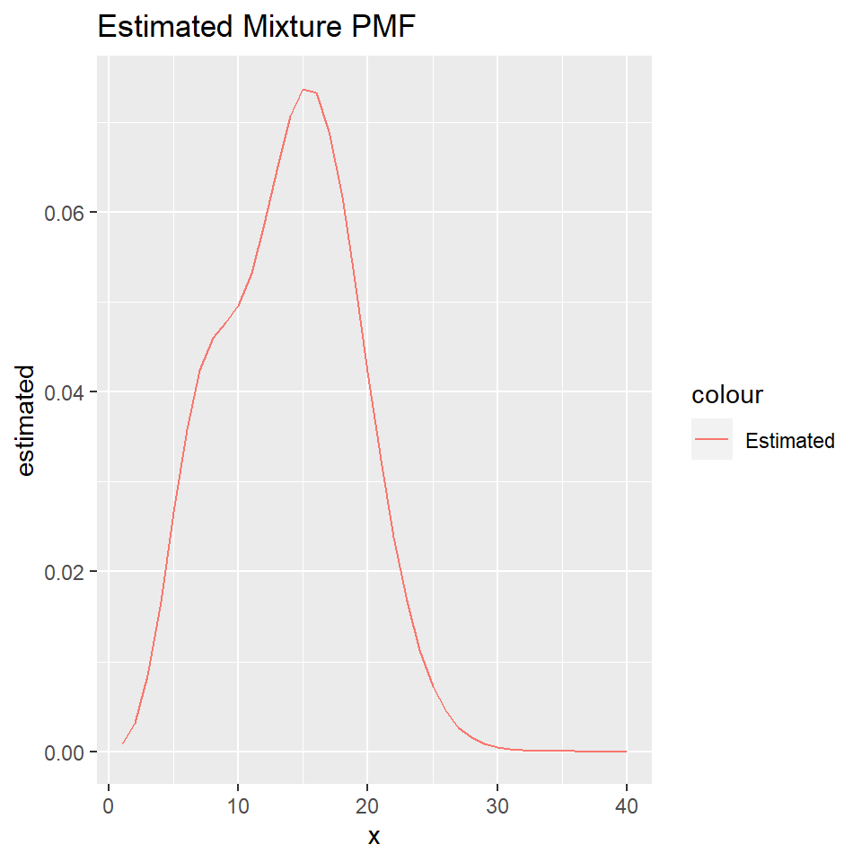

```r
# Create a PMF for the Poison Mixture Model
data.frame(x = 1:40,
           estimated = dpois(1:40, lambda = exp(model$beta[1]))*model$lambda[1] +
                       dpois(1:40, lambda = exp(model$beta[2]))*model$lambda[2]) %>%
  ggplot() +
    geom_line(aes(x = x, y = estimated, color = "Estimated")) +
    ggtitle("Estimated Mixture PMF")
```

The model parameters are $\pi_1 = 0.271686$, $\pi_2 = 0.728314$, $\lambda_1 = e^{2.064644} = 7.882491$ and $\lambda_2 = e^{2.781594} = 16.14473$

6. **2 pts Extra Credit**: Write a function that estimates this two-component mixture model using the EM approach. Show that it gives the same result as part *e*.
   - Note: you are not permitted to copy code. Write everything from scratch and use comments to indicate how the code works (e.g., the E-step, M-step, initialization strategy, and convergence should be clear).
   - Cite any resources you consulted to help with the coding.